# BAS改进:天牛群算法以及步长更新策略

# 1 问题背景

**建筑系统阻容模型的参数辨识**。问题的起源：我希望辨识一个好的灰箱模型，便于进行后续的建筑模型预测控制的研究。通用的做法是阻容(`RC`)模型，即将墙，空气都认为是具有热传导和热存储与释放特性的材料。可以将一个房间抽象为如图1所示的阻容模型。

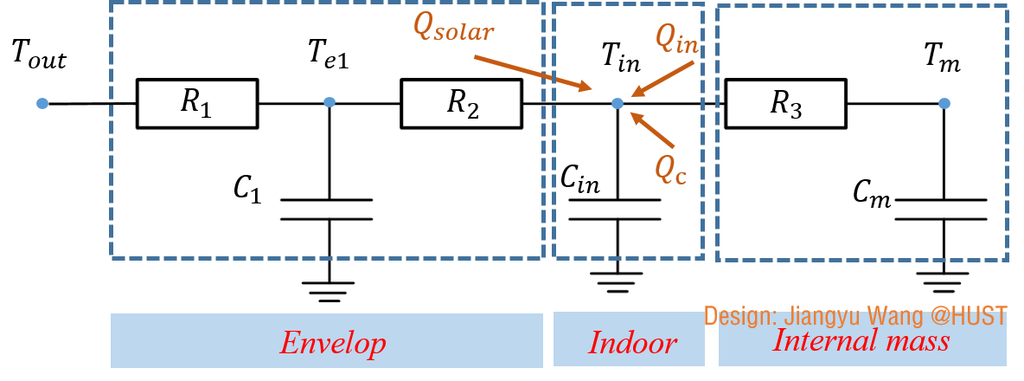

Fig.1 建筑物结构

**数学问题**。`RC`模型本质上是求解常微分方程组(`ODEs`)，而辨识`RC`模型则是拟合其中的系数。对于本问题，需要拟合的系数为：$R_1$,$R_2$,$R_3$,$T_{e1}$,$T_{in}$,$T_{m}$,$C_1$,$C_{in}$,$C_m$.数学模型如下：

# 2 辨识方法

由于我在数学优化上所知甚少，故此不多做使用方法原理上的介绍。

目标函数是求解微分方程得到的室内温度$T_{in,RC}$和实际的室内温度$T_{in,real}$的绝对差值的总和。

## 2.1 Levenberg-Marquardt algorithm

结果如图2所示。

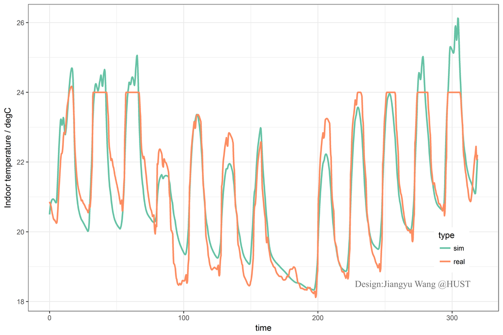

Fig.2 L-M算法辨识结果

由于`LM`算法耗时过长，故而萌发使用`BAS`算法进行辨识的想法。在此前的了解中，`BAS`的构造简单，很好地避免了大量的计算。心里预期是觉得`LM`为基于模型的算法，故而得到的结果较好(目标函数的值约为550`degC`左右)，希望`BAs`可以牺牲一定的准确性，快速辨识出可用的阻容参数。

## 2.2 原始BAS算法

最开始尝试了原始的BAS算法，观察到一个有意思的现象。如果我在程序中设定一个随机种子(`R`语言环境)，**在某个特定的随机种子下，算法能快速地收敛**，并得到一个较小地误差(约为850`degC`左右)。**这表明`BAS`是很依赖于初始值，以及生成的方向参数**。

- 但是存在如下3点问题:
  - 步长随着时间（迭代次数）衰减，但是很多次迭代不能保证天牛进行到更优的位置，因此，很多步长的衰减是浪费了;
  - 天牛位置更新同上，没有得到优化（目标更小的）天牛位置，不该成为下一步天牛的位置;
  - 在不同的数据下，随机种子不可能每次都能人为选定，我更希望能**真正随机**地选定初始值和方向时，算法最终也收敛到较好的结果。比如，我不设定随机种子，多次重复执行程序，也能收敛到600~800 `degC`。